# Exploratory Data Analysis

YLG

November 19, 2025

```r
df <- readr::read_csv("reviews_final.csv")
```

## Distribution of Reviews

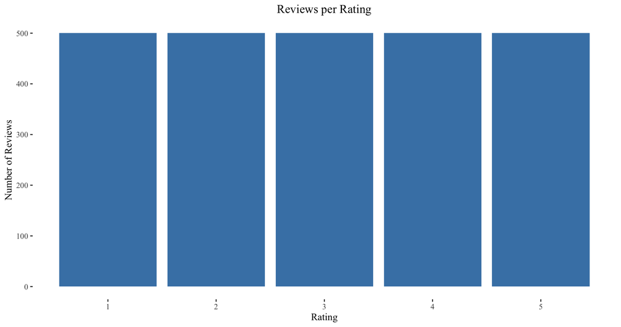

```r
ggplot(df, aes(x = Rating)) +
    geom_bar(fill = "steelblue") +
    labs(
    title = "Reviews per Rating",
    x = "Rating",
    y = "Number of Reviews"
  ) +
  theme_tufte(base_family = "Times New Roman") +
  theme(
    plot.title = element_text(hjust = 0.5),
    legend.position = "top"
    )
```

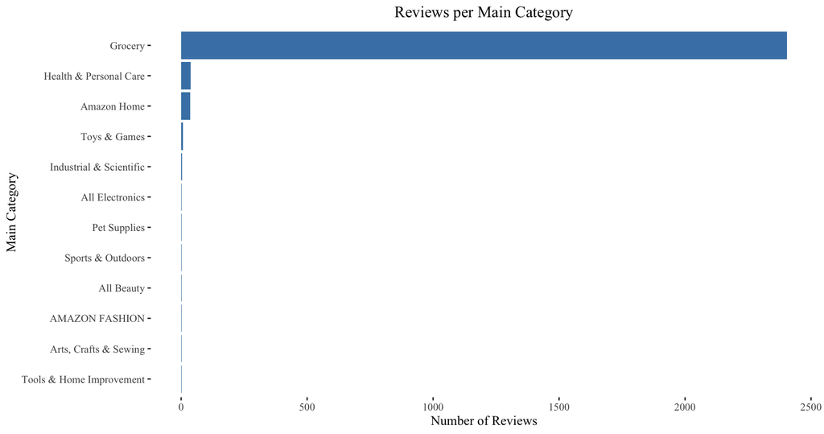

```r
ggplot(df, aes(x = fct_rev(fct_infreq(`Main Category`)))) +
  geom_bar(fill = "steelblue") +
  labs(
    title = "Reviews per Main Category",
    x = "Main Category",
    y = "Number of Reviews"
  ) +
  coord_flip() +
  theme_tufte(base_family = "Times New Roman") +
  theme(
    plot.title = element_text(hjust = 0.5),
    legend.position = "top"
  )
```

## Word & Sentence Counts

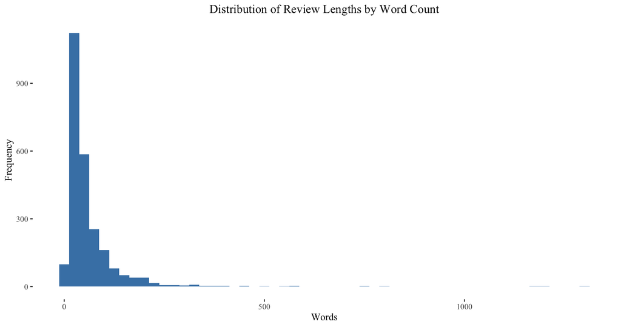

```r
ggplot(df, aes(x = `Word Count`)) +
  geom_histogram(fill = "steelblue", binwidth = 25) +
  labs(
    title = "Distribution of Review Lengths by Word Count",
    x = "Words",
    y = "Frequency"
  ) +
  theme_tufte(base_family = "Times New Roman") +
  theme(
    plot.title = element_text(hjust = 0.5),
    legend.position = "top"
  )
```

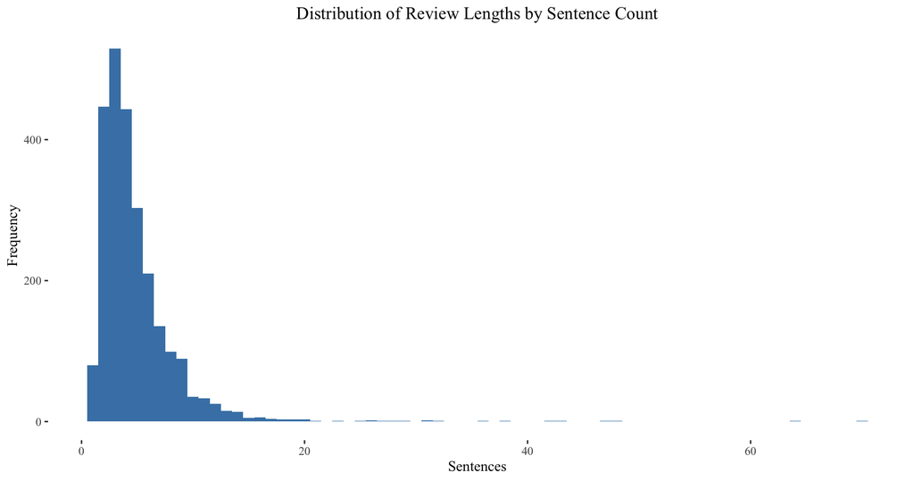

```r
ggplot(df, aes(x = `Sentence Count`)) +
  geom_histogram(fill = "steelblue", binwidth = 1) +
  labs(
    title = "Distribution of Review Lengths by Sentence Count",
    x = "Sentences",
    y = "Frequency"
  ) +
  theme_tufte(base_family = "Times New Roman") +
  theme(
    plot.title = element_text(hjust = 0.5),
    legend.position = "top"
  )
```

- High frequency of small counts (e.g., short reviews)
- Rapid drop-off as word count increases

A geometric distribution in word count suggests that the dataset is dominated by short, spontaneous, and unstructured text. It points to high-frequency short reviews, low content variance, and the need to consider how rare long reviews are handled — both in descriptive analysis and in transformer-based modelling.

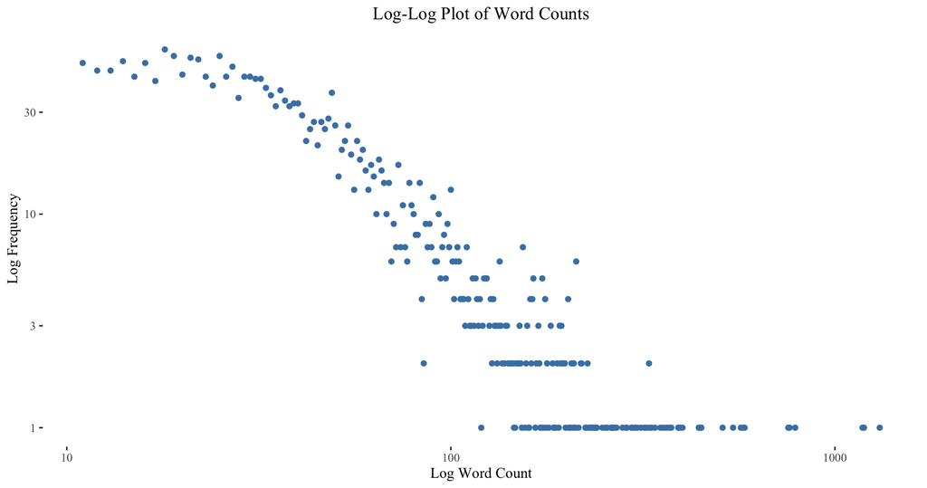

```r
df |>
    count(`Word Count`) |>
    ggplot(aes(x = `Word Count`, y = n)) +
    geom_point(color = "steelblue") +
    scale_x_log10() +
    scale_y_log10() +
    labs(title = "Log-Log Plot of Word Counts", x = "Log Word Count", y = "Log Frequency") +
  theme_tufte(base_family = "Times New Roman") +
  theme(
    plot.title = element_text(hjust = 0.5),
    legend.position = "top"
  )
```

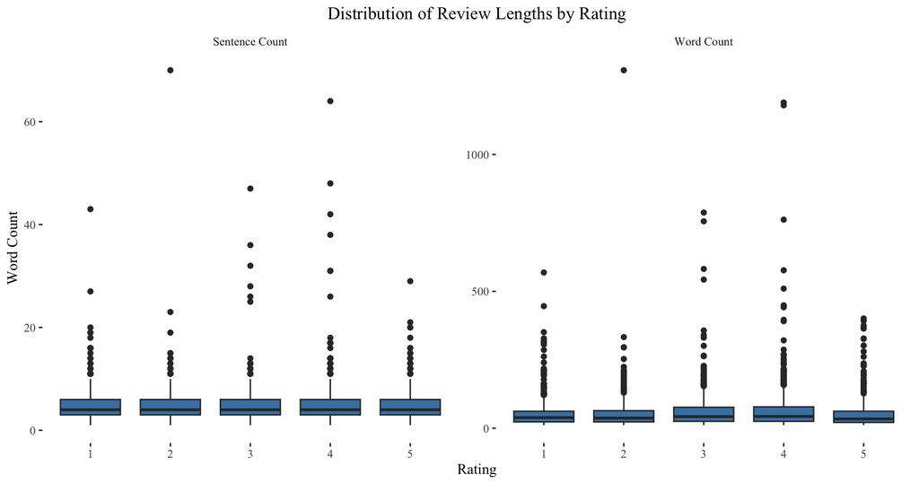

```r
df_boxplot <- df |>
  select(Rating, `Word Count`, `Sentence Count`) |>
  pivot_longer(
    cols = c(`Word Count`, `Sentence Count`),
    names_to = "metric",
    values_to = "value"
  )


ggplot(df_boxplot, aes(x = factor(Rating), y = value)) +
  geom_boxplot(fill = "steelblue") +
    facet_wrap(~metric, scales = "free_y") +
  labs(
    title = "Distribution of Review Lengths by Rating",
    x = "Rating",
    y = "Word Count"
  ) +
  theme_tufte(base_family = "Times New Roman") +
  theme(
    plot.title = element_text(hjust = 0.5),
    legend.position = "top"
  )
```

```r
# Generate summary statistics for the actual target variable
glance(summary(df$`Word Count`)) |>
    kable(
      caption = "Summary Statistics of the Word Count for Full Reviews",
      digits = 2
    ) |>
      kable_styling(
      position = "center",
    full_width = FALSE
  )
```

Table 1: Table 2: Summary Statistics of the Word Count for Full Reviews

| minimum | q1 | median | mean | q3 | maximum |
| --- | --- | --- | --- | --- | --- |
| 11 | 23 | 38 | 59.6 | 67 | 1308 |

```r
# # Generate summary statistics for the actual target variable
glance(summary(df$`Sentence Count`)) |>
    kable(
      caption = "Summary Statistics of the Sentence Count for Full Reviews",
      digits = 2
    ) |>
      kable_styling(
      position = "center",
    full_width = FALSE
  )
```

Table 3: Table 4: Summary Statistics of the Sentence Count for Full Reviews

| minimum | q1 | median | mean | q3 | maximum |
| --- | --- | --- | --- | --- | --- |
| 1 | 3 | 4 | 4.86 | 6 | 70 |

```r
get_modes <- function(v) {
  uniqv <- unique(v)
  freq <- tabulate(match(v, uniqv))
  uniqv[freq == max(freq)]
}

get_modes(df$`Sentence Count`)
```

```
[1] 3
```

## Word Cloud

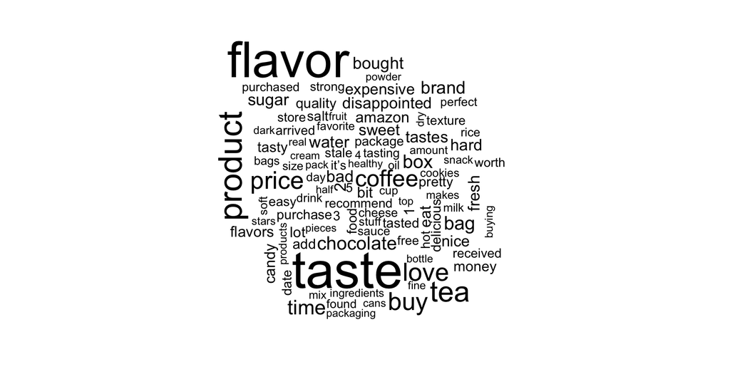

```r
library(tidytext)
library(dplyr)
library(stringr)
library(wordcloud)

custom_stopwords <- bind_rows(
  stop_words,
  tibble(word = c("it's", "i'm", "they're", "we're", "you'll"), lexicon = "custom")
)

word_counts <- df |>
  unnest_tokens(word, Review) |>
  filter(!word %in% custom_stopwords$word) |>
  count(word, sort = TRUE)

word_counts |>
  with(wordcloud(word, n, max.words = 100, colours = brewer.pal(8, "Blues")))
```

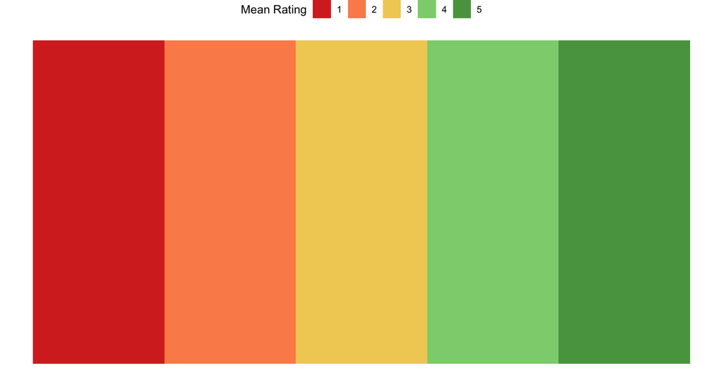

```r
# Create a dummy dataframe for the legend
legend_df <- data.frame(
  rating_group = factor(1:5),
  x = 1:5,
  y = 1
)

# Define colours for each rating level
rating_colours <- c(
  "1" = "#d73027",  # red
  "2" = "#fc8d59",  # orange
  "3" = "#F1CE63",  # yellow
  "4" = "#8CD17D",  # light green
  "5" = "#59A14F"   # dark green
)

# Create a custom legend
ggplot(legend_df, aes(x, y, fill = rating_group)) +
  geom_tile() +
  scale_fill_manual(values = rating_colours, name = "Mean Rating") +
  theme_void() +
  theme(legend.position = "top")
```

## TF-IDF & N-grams

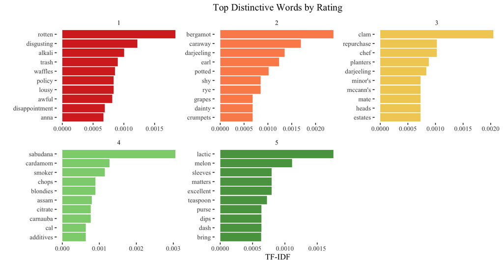

```r
library(tidytext)
library(textclean)
library(stringr)

# Tokenise by word and clean
word_tokens <- df |>
  mutate(Review = replace_contraction(Review)) |>
  unnest_tokens(word, Review) |>
  anti_join(custom_stopwords, by = "word") |>
  filter(!str_detect(word, "^\\d+$"))  # remove pure numbers

# Most common words per rating
word_freq <- word_tokens |>
  count(Rating, word, sort = TRUE)

# Distinctive words using TF-IDF
word_tf_idf <- word_freq |>
  bind_tf_idf(term = word, document = Rating, n = n) |>
  group_by(Rating) |>
  slice_max(tf_idf, n = 10, with_ties = FALSE) |>
  ungroup()

# Plot TF-IDF words
ggplot(word_tf_idf, aes(x = reorder_within(word, tf_idf, Rating), y = tf_idf, fill = as.factor(Rating))) +
  geom_col(show.legend = FALSE) +
  facet_wrap(~Rating, scales = "free") +
  scale_x_reordered() +
  scale_fill_manual(values = rating_colours) +
  labs(title = "Top Distinctive Words by Rating",
       x = "", y = "TF-IDF") +
  coord_flip() +
  theme_tufte(base_family = "Times New Roman") +
  theme(
    plot.title = element_text(hjust = 0.5),
    legend.position = "none"
  )
```

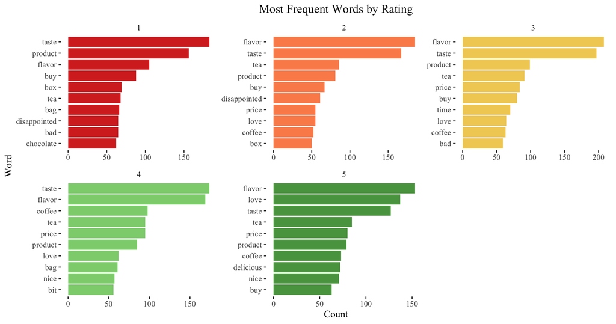

```r
# WORD analysis
words <- df |>
  mutate(Review = replace_contraction(Review)) |>
  unnest_tokens(word, Review, token = "words") |>
  filter(!word %in% custom_stopwords$word,
         !str_detect(word, "^\\d+$"))

# Count top words per rating
top_words <- words |>
  count(Rating, word, sort = TRUE) |>
  group_by(Rating) |>
  slice_max(n, n = 10, with_ties = FALSE) |>
  ungroup()

# Plot words
ggplot(top_words, aes(x = reorder_within(word, n, Rating), y = n, fill = as.factor(Rating))) +
  geom_col(show.legend = FALSE) +
  facet_wrap(~Rating, scales = "free") +
  scale_x_reordered() +
  scale_fill_manual(values = rating_colours) +
  labs(title = "Most Frequent Words by Rating",
       x = "Word", y = "Count") +
  coord_flip() +
  theme_tufte(base_family = "Times New Roman") +
  theme(
    plot.title = element_text(hjust = 0.5),
    legend.position = "none"
  )
```

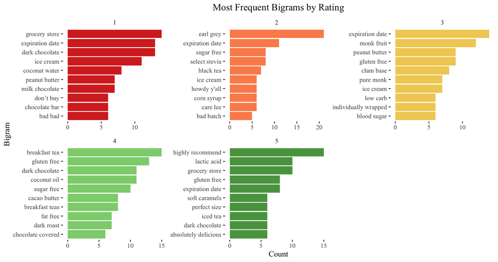

```r
# BIGRAM analysis
bigrams <- df |>
  mutate(Review = replace_contraction(Review)) |>
  unnest_tokens(bigram, Review, token = "ngrams", n = 2)

# Separate and remove stop words from bigrams
bigrams_separated <- bigrams |>
  separate(bigram, into = c("word1", "word2"), sep = " ") |>
  filter(!word1 %in% custom_stopwords$word,
         !word2 %in% custom_stopwords$word,
         !str_detect(word1, "^\\d+$"),
         !str_detect(word2, "^\\d+$")) |>
  unite(bigram, word1, word2, sep = " ")

# Count top bigrams per rating
top_bigrams <- bigrams_separated |>
  count(Rating, bigram, sort = TRUE) |>
  group_by(Rating) |>
  slice_max(n, n = 10, with_ties = FALSE) |>
  ungroup()

# Plot bigrams
ggplot(top_bigrams, aes(x = reorder_within(bigram, n, Rating), y = n, fill = as.factor(Rating))) +
  geom_col(show.legend = FALSE) +
  facet_wrap(~Rating, scales = "free") +
  scale_x_reordered() +
  scale_fill_manual(values = rating_colours) +
  labs(title = "Most Frequent Bigrams by Rating",
       x = "Bigram", y = "Count") +
  coord_flip() +
  theme_tufte(base_family = "Times New Roman") +
  theme(
    plot.title = element_text(hjust = 0.5),
    legend.position = "none"
  )
```

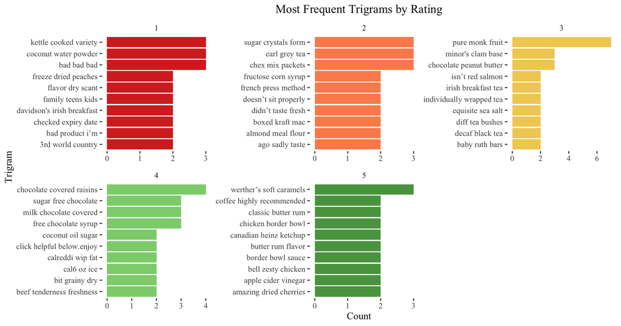

```r
# TRIGRAM analysis
trigrams <- df |>
  mutate(Review = replace_contraction(Review)) |>
  unnest_tokens(trigram, Review, token = "ngrams", n = 3)

# Separate and remove stop words from trigrams
trigrams_separated <- trigrams |>
  separate(trigram, into = c("word1", "word2", "word3"), sep = " ") |>
  filter(
    !word1 %in% custom_stopwords$word,
    !word2 %in% custom_stopwords$word,
    !word3 %in% custom_stopwords$word,
    !str_detect(word1, "^\\d+$"),
    !str_detect(word2, "^\\d+$"),
    !str_detect(word3, "^\\d+$")
  ) |>
  unite(trigram, word1, word2, word3, sep = " ")

# Count top trigrams per rating
top_trigrams <- trigrams_separated |>
  count(Rating, trigram, sort = TRUE) |>
  group_by(Rating) |>
  slice_max(n, n = 10, with_ties = FALSE) |>
  ungroup()

# Plot trigrams
ggplot(top_trigrams, aes(x = reorder_within(trigram, n, Rating), y = n, fill = as.factor(Rating))) +
  geom_col(show.legend = FALSE) +
  facet_wrap(~Rating, scales = "free") +
  scale_x_reordered() +
  scale_fill_manual(values = rating_colours) +
  labs(title = "Most Frequent Trigrams by Rating",
       x = "Trigram", y = "Count") +
  coord_flip() +
  theme_tufte(base_family = "Times New Roman") +
  theme(
    plot.title = element_text(hjust = 0.5),
    legend.position = "none"
  )
```

## Sentiment vs. Rating

When comparing text-based sentiment scores to the actual star ratings, this can reveal:

- Misalignments (e.g., 5-star ratings with negative sentiment)
- Review quality or credibility issues

Explore misalignments, for example: filter for 1-star or 2-star reviews with high positive sentiment, or 5-star reviews with negative sentiment.

The mismatches could be due to failure of the model to consider context, especially if reviews were editted later.

To visualise sentiment–rating mismatches, a good approach is to plot sentiment scores against star ratings and highlight misaligned reviews.

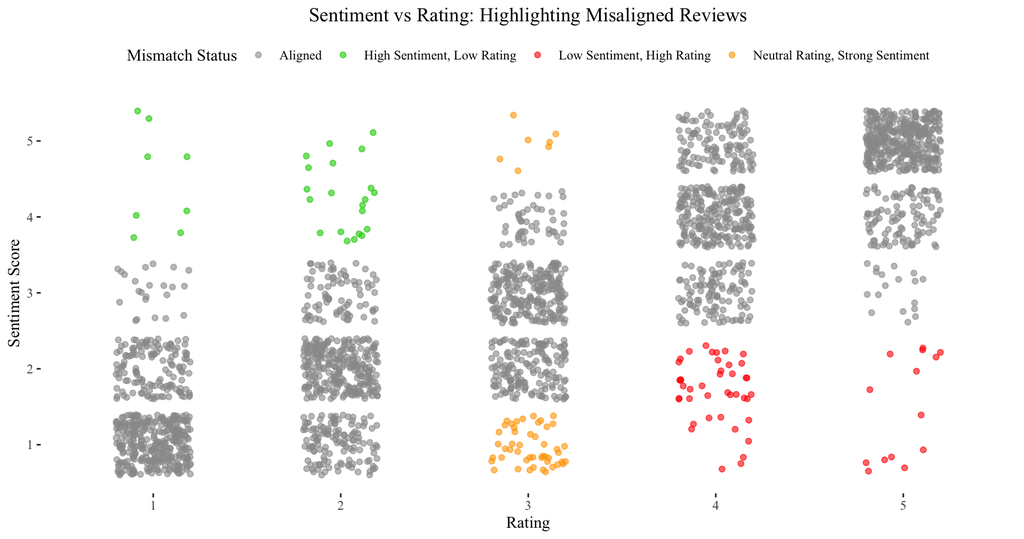

```r
df_emotions <- readr::read_csv("reviews_final.csv")

# Example thresholds for misalignment
threshold_positive <- 4   # unusually high sentiment for low rating
threshold_negative <- 3  # unusually low sentiment for high rating

misaligned_reviews <- df_emotions |>
  filter(
    (Rating <= 2 & `Sentiment Score` > threshold_positive) |
    (Rating >= 4 & `Sentiment Score` < threshold_negative)
  )


# Add mismatch classification
reviews_df <- df_emotions |>
  mutate(misaligned = case_when(
    Rating <= 2 & `Sentiment Score` >= threshold_positive ~ "High Sentiment, Low Rating",
    Rating >= 4 & `Sentiment Score` < threshold_negative ~ "Low Sentiment, High Rating",
    Rating == 3 & (`Sentiment Score` > 4 | `Sentiment Score` < 2) ~ "Neutral Rating, Strong Sentiment",
    TRUE ~ "Aligned"
  ))

# Visualise
ggplot(reviews_df, aes(x = factor(Rating), y = `Sentiment Score`, colour = misaligned)) +
  geom_jitter(width = 0.2, alpha = 0.6) +
  scale_colour_manual(values = c("High Sentiment, Low Rating" = "green3",
                                 "Low Sentiment, High Rating" ="red",
                                 "Neutral Rating, Strong Sentiment" = "orange",
                                 "Aligned" = "grey60")) +
  labs(x = "Rating", y = "Sentiment Score",
       title = "Sentiment vs Rating: Highlighting Misaligned Reviews",
       colour = "Mismatch Status") +
  theme_tufte(base_family = "Times New Roman") +
  theme(
    plot.title = element_text(hjust = 0.5),
    legend.position = "top"
  )
```

```r
library(dplyr)
library(psych)

df |>
  select(where(is.numeric), -`Word Count`) |>
  psych::describe()
```

```
                  vars    n mean   sd median trimmed  mad min   max range  skew
Rating               1 2500 3.00 1.41   3.00    3.00 1.48   1  5.00  4.00  0.00
Sentence Count       2 2500 4.86 4.08   4.00    4.23 1.48   1 70.00 69.00  6.02
Sentiment Score      3 2500 2.90 1.43   3.00    2.87 1.48   1  5.00  4.00  0.16
Disgust              4 2500 0.21 0.29   0.06    0.15 0.08   0  0.99  0.99  1.46
Neutral              5 2500 0.35 0.30   0.28    0.33 0.35   0  0.96  0.96  0.49
Surprise             6 2500 0.09 0.19   0.02    0.04 0.02   0  0.98  0.98  3.15
Sadness              7 2500 0.12 0.23   0.02    0.06 0.02   0  0.99  0.99  2.42
Anger                8 2500 0.03 0.08   0.01    0.01 0.01   0  0.92  0.92  6.23
Fear                 9 2500 0.01 0.07   0.00    0.00 0.00   0  0.97  0.97  9.59
Joy                 10 2500 0.18 0.28   0.02    0.11 0.02   0  0.99  0.99  1.62
Not as Expected     11 2500 0.80 0.28   0.95    0.86 0.07   0  1.00  1.00 -1.50
Damaged             12 2500 0.54 0.37   0.59    0.55 0.55   0  1.00  1.00 -0.15
Returns             13 2500 0.41 0.26   0.40    0.40 0.31   0  1.00  1.00  0.28
Taste and Flavour   14 2500 0.74 0.26   0.84    0.78 0.18   0  1.00  1.00 -1.18
Size and Quantity   15 2500 0.40 0.27   0.35    0.38 0.30   0  0.99  0.99  0.50
Freshness           16 2500 0.44 0.25   0.46    0.44 0.26   0  1.00  1.00 -0.13
Price               17 2500 0.59 0.22   0.60    0.60 0.22   0  1.00  1.00 -0.34
Packaging           18 2500 0.36 0.31   0.29    0.33 0.33   0  1.00  1.00  0.61
Quality             19 2500 0.54 0.36   0.58    0.54 0.53   0  1.00  1.00 -0.17
Delivery            20 2500 0.41 0.24   0.40    0.40 0.26   0  0.99  0.99  0.32
Ingredients         21 2500 0.41 0.20   0.42    0.41 0.21   0  1.00  1.00 -0.03
Value for Money     22 2500 0.54 0.34   0.56    0.55 0.50   0  1.00  1.00 -0.12
Expiration Date     23 2500 0.21 0.20   0.15    0.18 0.15   0  0.99  0.99  1.71
Easy to Use         24 2500 0.30 0.33   0.13    0.26 0.20   0  1.00  1.00  0.77
                  kurtosis   se
Rating               -1.30 0.03
Sentence Count       65.17 0.08
Sentiment Score      -1.31 0.03
Disgust               0.76 0.01
Neutral              -1.16 0.01
Surprise              9.69 0.00
Sadness               4.83 0.00
Anger                46.40 0.00
Fear                104.18 0.00
Joy                   1.20 0.01
Not as Expected       1.01 0.01
Damaged              -1.59 0.01
Returns              -0.89 0.01
Taste and Flavour     0.46 0.01
Size and Quantity    -0.76 0.01
Freshness            -0.81 0.00
Price                -0.22 0.00
Packaging            -0.88 0.01
Quality              -1.54 0.01
Delivery             -0.59 0.00
Ingredients          -0.46 0.00
Value for Money      -1.45 0.01
Expiration Date       3.26 0.00
Easy to Use          -0.90 0.01
```

```r
Hmisc::describe(df)
```

```
df

 32  Variables      2500  Observations
--------------------------------------------------------------------------------
Rating
       n  missing distinct     Info     Mean  pMedian      Gmd
    2500        0        5     0.96        3        3    1.601

Value        1   2   3   4   5
Frequency  500 500 500 500 500
Proportion 0.2 0.2 0.2 0.2 0.2

For the frequency table, variable is rounded to the nearest 0
--------------------------------------------------------------------------------
Parent Asin
       n  missing distinct
    2500        0     2201

lowest : B0000VM8R2 B00017028M B0001JXDTA B00026O5D0 B00027VBBS
highest: B0CCKX8GCQ B0CD3PG651 B0CDLRTR5L B0CG3Q42VJ B0CG58PK8K
--------------------------------------------------------------------------------
Main Category
       n  missing distinct
    2500        0       12

lowest : All Beauty               All Electronics          AMAZON FASHION           Amazon Home              Arts, Crafts & Sewing
highest: Industrial & Scientific  Pet Supplies             Sports & Outdoors        Tools & Home Improvement Toys & Games
--------------------------------------------------------------------------------
Product Title
       n  missing distinct
    2500        0     2200

lowest : (1) 2.5 oz Mini Snack Size Package Hershey’s Heath Milk Chocolate English Toffee Bar Candy (5 Miniatures bars per package .5 oz each)                                                 (2 Pack) Washburns Old Fashioned Hard Candy ( 8 oz Canisters)                                                …
highest: Zatarain's New Orleans Style Big Easy Dirty Rice Mix, Easy Rice, 8.8 oz (Pack of 8)                                                                                                   ZenSweet Monk Fruit Sweetener - 1:1 Sugar Substitute - 1lb - Zero Calorie, Zero Glycemic Index - Gluten-Free,…
--------------------------------------------------------------------------------
Retailer
       n  missing distinct
    2500        0     1399

lowest : "SLAP YA MAMA"            1850                      205° PERFECT COFFEE       365                       365 by Whole Foods Market
```

[output cut: 224 more lines]

```
        n   missing  distinct      Info      Mean   pMedian       Gmd       .05
     2500         0      2494         1    0.2978    0.2816    0.3558 0.0005011
      .10       .25       .50       .75       .90       .95
0.0011060 0.0089031 0.1349830 0.5716939 0.8336486 0.9335860

lowest : 8.77086e-05 9.81218e-05 0.000103585 0.000104377 0.000111771
highest: 0.998298    0.99846     0.99888     0.998926    0.998966
--------------------------------------------------------------------------------
Dominant Topic
       n  missing distinct
    2500        0       15

lowest : Damaged           Delivery          Easy to Use       Expiration Date   Freshness
highest: Quality           Returns           Size and Quantity Taste and Flavour Value for Money
--------------------------------------------------------------------------------
```

```r
df_sampled <- readr::read_csv("reviews_clean.csv")

# Summary of detected anomalies in the dataset
anomalies <- xray::anomalies(df_sampled)

knitr::kable(
  anomalies$variables,
  caption = "Summary of Detected Anomalies in the Stratified Sample")
```

Table 5: Summary of Detected Anomalies in the Stratified Sample

| Variable | q | qNA | pNA | qZero | pZero | qBlank | pBlank | qInf | pInf | qDistinct | type | anomalous_percent |
| --- | --- | --- | --- | --- | --- | --- | --- | --- | --- | --- | --- | --- |
| Rating | 2500 | 0 | - | 0 | - | 0 | - | 0 | - | 5 | Numeric | - |
| Main Category | 2500 | 0 | - | 0 | - | 0 | - | 0 | - | 12 | Character | - |
| Sentence Count | 2500 | 0 | - | 0 | - | 0 | - | 0 | - | 37 | Numeric | - |
| Word Count | 2500 | 0 | - | 0 | - | 0 | - | 0 | - | 248 | Numeric | - |
| Retailer | 2500 | 0 | - | 0 | - | 0 | - | 0 | - | 1399 | Character | - |
| Product Title | 2500 | 0 | - | 0 | - | 0 | - | 0 | - | 2200 | Character | - |
| Parent Asin | 2500 | 0 | - | 0 | - | 0 | - | 0 | - | 2201 | Character | - |
| Review | 2500 | 0 | - | 0 | - | 0 | - | 0 | - | 2494 | Character | - |